# Natural Disasters and Stock Market Volatility

# 1. Introduction

Natural disasters are significant events that disrupt human lives, infrastructure, and economies. Their impacts extend beyond the physical and humanitarian toll, reverberating through financial systems, including stock markets. As the frequency and intensity of disasters such as Floods, Tropical Cyclones, and Severe Storms increase—likely exacerbated by climate change—understanding their economic consequences becomes ever more crucial. While broad market indices may offer insights into overall market stability, industry-specific analyses can reveal vulnerabilities and resilience within sectors closely tied to regional and disaster-specific factors.

This project explores the financial implications of natural disasters by examining stock price movements across industries in the U.S. Using data from the NOAA Billion-Dollar Disaster Database and stock market datasets, our research aims to quantify the abnormal returns experienced by companies in the real estate, utilities, and healthcare sectors during and after disasters. By analyzing disasters with varying geographic and economic footprints, such as Floods, Tropical Cyclones, and severe storms, we aim to provide actionable insights into disaster-specific market responses and their impact on investor behavior.

## Research Question

What are the immediate and short-term financial impacts of extreme natural disasters, such as **Floods, Tropical Cyclones, and Severe Storms** on the stock prices of U.S. companies, and how do these impacts vary across industries?

## Motivation

Our motivation for this study stems from the need to:

1. **Understand Localized Impacts:** Industries like real estate and utilities are inherently tied to specific regions, making them highly sensitive to localized disasters. A Flood in Florida or a Tropical Cyclone in Texas, for example, could directly impact property values, infrastructure, and revenue streams for companies headquartered in those areas.
2. **Inform Investment Decisions:** Identifying patterns in stock price movements during disaster periods can help investors and portfolio managers make more informed decisions about risk and diversification strategies.
3. **Support Policy Development:** Insights from this research can guide policymakers in designing resilience measures, such as improved disaster preparedness and industry-specific support mechanisms.

## Methodology

To analyze the financial impacts of natural disasters on industry-specific stock performance by:

1. Quantifying **abnormal returns (AR)** and **cumulative abnormal return (CAAR)** for companies during disaster periods, based on **event study** methodology.
2. Comparing the responses of different industries (e.g., real estate, utilities, and healthcare) to specific disaster types (Floods, Tropical Cyclones, and Severe Storms).

# 2. Research Process and Theoretical Framework

## Data Sources

**Natural Disaster Data:**

1. NOAA Billion-Dollar Disaster Database, detailing disaster type, location, and economic costs.

**Stock Market Data:**

1. Daily price data for companies in the S&P 500, categorized by industry.
2. S&P 500 index data for calculating market returns.

## Analysis Process

1. **Event Study Approach:**
- Event studies analyze the effect of a specific event—in this case, a natural disaster—on stock prices over a defined period.
- The event window captures stock price movements from 30 days before to 30 days after the disaster, while the estimation window establishes a baseline for normal returns.
2. **Calculating Returns:**
- **Daily Return (R):** The percentage change in a stock’s price from one day to the next.
- **Market Return (Rm):** The daily return of the S&P 500 index, representing overall market performance.
- **Risk-Free Return (Rf):** A theoretical return with zero risk, typically approximated using treasury bond rates.
3. **Abnormal Return (AR):**
- The difference between a stock's actual return and its expected return, calculated using beta (sensitivity to market changes):

$$ AR_t = R_t - (\beta \times R_m + R_f) $$

4. **Average Abnormal Return (AAR):**
- The average abnormal return across all companies in a given industry or event group.
5. **Cumulative Abnormal Return (CAAR):**
- The sum of AARs over the event window, representing the aggregated effect of the disaster:

$$ CAAR = \sum_{t=-30}^{30} AAR_t $$

6. **Visualization:**
- Plotting CAAR over time for different industries and disaster types to compare recovery patterns and long-term impacts.

# 3. Setting Up the Development Environment

Before we begin, we will import all the useful packages we will need to proceed.

```python
# %pip install --upgrade yfinance==0.2.54
# %pip install scikit-learn
# %pip install statsmodels
```

```python
import pandas as pd
import numpy as np
import matplotlib.pyplot as plt
import seaborn as sns
import yfinance as yf
from sklearn.linear_model import LinearRegression
import statsmodels.api as sm
import time

%matplotlib inline
```

# 4. Parameters Setting

Firstly, we define the key parameters for our analysis to delve into out event study approach:

These parameters provide the foundation for filtering data and conducting targeted analyses.

```python
# We have SP500 data only include dates after 2014-11-24
# Examples:
start_date = '2014-11-24'
end_date = '2023-12-31'
industry_name = 'Utilities'
disaster_type = 'Flooding'
day_num = 30  # The time window we are reasearching
```

# 5. Raw Data Cleaning

## Disaster -- Raw Data

### Reading and Cleaning Disaster Data

We process state-specific disaster data for all 50 states, Washington D.C., and U.S. territories using a predefined list of state abbreviations. The `clean_location_data` function is designed to read each state's dataset, add a `Location` column to identify the state, and format the `Begin Date` and `End Date` columns consistently. These individual datasets are then concatenated into a single comprehensive DataFrame, `location_based_df`. This combined dataset includes both national-level and state-level disasters, making it suitable for analyzing regional impacts and matching disasters to specific company locations.

```python
# List of states
states = ["AK", "AL", "AR", "AZ", "CA", "CO", "CT", "DC", "DE", "FL", "GA", "GU",
          "HI", "IA", "ID", "IL", "IN", "KS", "KY", "LA", "MA", "MD", "ME", "MI",
          "MN", "MO", "MS", "MT", "NC", "ND", "NE", "NH", "NJ", "NM", "NV", "NY",
          "OH", "OK", "OR", "PA", "PR", "RI", "SC", "SD", "TN", "TX", "UT", "VA",
          "VI", "VT", "WA", "WI", "WV", "WY"]

# Function to clean and format location-based datasets
def clean_location_data(state):
    file_path = f"Location-Based Data/{state}.csv"
    df = pd.read_csv(file_path, skiprows=2)
    df['Location'] = state  # Add state name as a column
    df['Begin Date'] = pd.to_datetime(df['Begin Date'], format='%Y%m%d')
    df['End Date'] = pd.to_datetime(df['End Date'], format='%Y%m%d')
    return df

# Clean and concatenate all state data
location_based_df = pd.concat([clean_location_data(state) for state in states], ignore_index=True)
location_based_df
```

|  | Name | Disaster | Begin Date | End Date | CPI-Adjusted Cost | Unadjusted Cost | Deaths | Location |
| --- | --- | --- | --- | --- | --- | --- | --- | --- |
| 0 | Western Fire Season (Fall 2002) | Wildfire | 2002-09-01 | 2002-11-30 | 2301.8 | 1322.8 | 21 | AK |
| 1 | California Wildfires (Fall 2003) | Wildfire | 2003-09-01 | 2003-11-30 | 6613.7 | 3890.4 | 22 | AK |
| 2 | Numerous Wildfires (2006) | Wildfire | 2006-01-01 | 2006-12-31 | 2332.8 | 1467.1 | 28 | AK |
| 3 | Western Wildfires (Summer 2007) | Wildfire | 2007-06-01 | 2007-08-31 | 4139.4 | 2741.3 | 12 | AK |
| 4 | Western Wildfires (Summer-Fall 2009) | Wildfire | 2009-06-01 | 2009-11-30 | 1477.4 | 1011.9 | 10 | AK |
| ... | ... | ... | ... | ... | ... | ... | ... | ... |
| 3490 | Western Wildfires (2021) | Wildfire | 2021-06-01 | 2021-12-31 | 12064.0 | 10400.0 | 8 | WY |
| 3491 | Western Drought and Heat Wave (2021) | Drought | 2021-01-01 | 2021-12-31 | 10117.2 | 8431.0 | 229 | WY |
| 3492 | Western/Central Drought and Heat Wave (2022) | Drought | 2022-01-01 | 2022-12-31 | 23480.6 | 20965.0 | 136 | WY |
| 3493 | Rockies Hail Storms and Central and Eastern Se... | Severe Storm | 2023-06-21 | 2023-06-26 | 5401.4 | 5244.0 | 8 | WY |
| 3494 | Central Severe Weather (June 2023) | Severe Storm | 2023-06-28 | 2023-07-02 | 1976.8 | 1919.0 | 3 | WY |

3495 rows × 8 columns

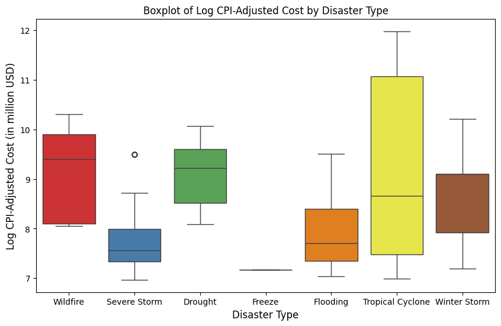

```python
# Extract relevant columns
selected_disaster_data = location_based_df.query('`Begin Date` > @start_date and `End Date` < @end_date')[['Disaster', 'CPI-Adjusted Cost']]
selected_disaster_data['Log CPI-Adjusted Cost'] = np.log(pd.to_numeric(selected_disaster_data['CPI-Adjusted Cost'])) # Logarithmize the cost

# Create a scatter plot using seaborn, where each disaster type is categorized by color
plt.figure(figsize=(10, 6))
sns.boxplot(x='Disaster', y='Log CPI-Adjusted Cost', data=selected_disaster_data, palette='Set1', hue='Disaster')

# Set plot titles and labels
plt.title('Boxplot of Log CPI-Adjusted Cost by Disaster Type')
plt.xlabel('Disaster Type', fontsize=12)
plt.ylabel('Log CPI-Adjusted Cost (in million USD)', fontsize=12)

# Display the plot
plt.show()
```

### Filtering Short-Duration Disasters

To ensure the reliability of our analysis, this code calculates the duration of each disaster and filters out events that last for extended periods. The column `day_num` is created by subtracting the `Begin Date` from the `End Date`, giving the duration of each disaster in days. Next, we calculate the average duration of disasters for each type, such as Flooding or Tropical Cyclones, using a group-by operation. This step helps identify which disaster types are typically short-lived.

The focus on short-duration disasters is critical because stock price changes over extended periods may be influenced by other unrelated factors, introducing noise into the analysis. By narrowing the dataset to disasters with direct, short-term impacts, we aim to isolate the financial effects of the disaster itself. This ensures that the stock price movements we analyze are more likely to reflect the immediate consequences of the disaster, rather than broader market trends or unrelated events.

```python
location_based_df['day_num']=location_based_df['End Date']-location_based_df['Begin Date']
location_based_df.loc[:, ['Disaster', 'day_num']].groupby('Disaster').mean()
```

| Disaster | day_num |
| --- | --- |
| Drought | 234 days 21:29:18.139534884 |
| Flooding | 33 days 09:33:03.673469388 |
| Freeze | 7 days 14:35:40.540540540 |
| Severe Storm | 3 days 01:39:57.934595524 |
| Tropical Cyclone | 3 days 12:54:48.188976377 |
| Wildfire | 176 days 02:10:12.765957446 |
| Winter Storm | 5 days 08:53:11.939546599 |

Based on the average duration, we select the events with the shortest durations for event analysis, excluding Drought and Wildfire.

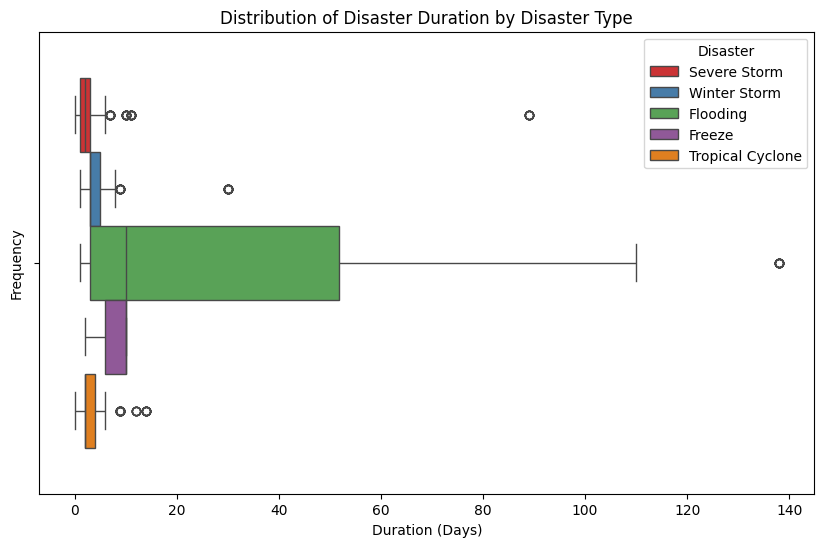

```python
location_based_df['int_day_num'] = location_based_df.day_num.dt.days
location_based_df = location_based_df[~location_based_df['Disaster'].isin(['Wildfire', 'Drought'])]
# Plot the distribution of disaster durations by disaster type
plt.figure(figsize=(10, 6))
sns.boxplot(data=location_based_df, x='int_day_num', hue='Disaster', palette='Set1')

# Set the title and labels for the axes
plt.title('Distribution of Disaster Duration by Disaster Type')
plt.xlabel('Duration (Days)')
plt.ylabel('Frequency')

# Display the plot
plt.show()
```

Given that the analysis aims to focus on events with shorter durations to facilitate detailed event analysis, it is reasonable to exclude flooding events that last longer than 20 days. This exclusion will help in focusing on events that are more typical and less influenced by extreme duration outliers, thus providing a more consistent dataset for analysis.

```python
# Filter the flooding events that lasted longer than 20 days
location_based_df = location_based_df[~((location_based_df.Disaster=='Flooding')&(location_based_df.int_day_num>20))]
location_based_df.query('`Begin Date` > @start_date and `End Date` < @end_date')['Disaster'].value_counts()
```

```
Disaster
Severe Storm        851
Tropical Cyclone    143
Winter Storm        105
Flooding             76
Freeze                9
Name: count, dtype: int64
```

Additionally, we also exclude disaster types that occurred only a few times during the study period to ensure statistical robustness, such as Freeze.

So, we identify Severe Storms, Tropical Cyclones, Winter Storms, and Flooding as suitable research subjects.

## S&P500 -- Raw Data

### Loading and Preprocessing the S&P 500 Data

This section of the code handles the preprocessing of stock data and company information required for our analysis.

First, we load the daily price data for the S&P 500 index from 2014 onward, ensuring that the dataset aligns with the timeframe of our research. The stock market data includes prices and dates, which are parsed and indexed for further calculations.

Next, the location-based disaster data is filtered to include only disasters that occurred after November 24, 2014, to match the stock market data's start date. This ensures consistency in the analysis window and avoids using mismatched datasets.

The code then processes the S&P 500 companies dataset, which includes information about company headquarters and sectors. To standardize the data, company locations are extracted and mapped to state abbreviations. Any companies headquartered outside the U.S. are labeled accordingly to distinguish them from domestic firms.

Finally, companies are grouped by their Global Industry Classification Standard (GICS) sector, which allows us to isolate specific industries, such as real estate. This grouping is crucial for conducting industry-specific analyses later in the study.

```python
# Load and preprocess the S&P 500 index data
SP500 = pd.read_csv('S&P  500.csv', parse_dates=['Date'], index_col='Date')
# SP500 data only include dates after 2014-11-24
location_based_df = location_based_df[location_based_df['Begin Date'] > pd.to_datetime(start_date)]

# Load and preprocess the S&P 500 companies data
state_abbreviations = {
    'Alabama': 'AL', 'Alaska': 'AK', 'Arizona': 'AZ', 'Arkansas': 'AR', 'California': 'CA',
    'Colorado': 'CO', 'Connecticut': 'CT', 'Delaware': 'DE', 'Florida': 'FL', 'Georgia': 'GA',
    'Hawaii': 'HI', 'Idaho': 'ID', 'Illinois': 'IL', 'Indiana': 'IN', 'Iowa': 'IA',
    'Kansas': 'KS', 'Kentucky': 'KY', 'Louisiana': 'LA', 'Maine': 'ME', 'Maryland': 'MD',
    'Massachusetts': 'MA', 'Michigan': 'MI', 'Minnesota': 'MN', 'Mississippi': 'MS',
    'Missouri': 'MO', 'Montana': 'MT', 'Nebraska': 'NE', 'Nevada': 'NV', 'New Hampshire': 'NH',
    'New Jersey': 'NJ', 'New Mexico': 'NM', 'New York': 'NY', 'North Carolina': 'NC',
    'North Dakota': 'ND', 'Ohio': 'OH', 'Oklahoma': 'OK', 'Oregon': 'OR', 'Pennsylvania': 'PA',
    'Puerto Rico': 'PR', 'Rhode Island': 'RI', 'South Carolina': 'SC', 'South Dakota': 'SD',
    'Tennessee': 'TN', 'Texas': 'TX', 'Utah': 'UT', 'Vermont': 'VT', 'Virginia': 'VA',
    'Washington': 'WA', 'West Virginia': 'WV', 'Wisconsin': 'WI', 'Wyoming': 'WY'
}

SP500_companies = (
    pd.read_csv('S&P_500_companies.csv')
    .rename(columns={'Headquarters Location': 'Location'})  # Standardize column name
)
# Extract state and map full names to abbreviations
SP500_companies['Location'] = (
    SP500_companies['Location']
    .str.split(" - ").str[-1]
    .map(state_abbreviations)
    .fillna("Outside the US")
)

# Group companies by sector and extract the Real Estate group
grouped_data = SP500_companies.groupby('GICS\xa0Sector')['Symbol'].apply(list)
```

Let's view our GICS Sector grouped data:

```python
grouped_data
```

```
GICS Sector
Communication Services    [GOOGL, GOOG, T, CHTR, CMCSA, EA, FOXA, FOX, I...
Consumer Discretionary    [ABNB, AMZN, APTV, AZO, BBY, BKNG, BWA, CZR, K...
Consumer Staples          [MO, ADM, BF.B, BG, CPB, CHD, CLX, KO, CL, CAG...
Energy                    [APA, BKR, CVX, COP, CTRA, DVN, FANG, EOG, EQT...
Financials                [AFL, ALL, AXP, AIG, AMP, AON, ACGL, AJG, AIZ,...
Health Care               [ABT, ABBV, A, ALGN, AMGN, BAX, BDX, TECH, BII...
Industrials               [MMM, AOS, ALLE, AMTM, AME, ADP, AXON, BA, BR,...
Information Technology    [ACN, ADBE, AMD, AKAM, APH, ADI, ANSS, AAPL, A...
Materials                 [APD, ALB, AMCR, AVY, BALL, CE, CF, CTVA, DOW,...
Real Estate               [ARE, AMT, AVB, BXP, CPT, CBRE, CSGP, CCI, DLR...
Utilities                 [AES, LNT, AEE, AEP, AWK, ATO, CNP, CMS, ED, C...
Name: Symbol, dtype: object
```

## Risk-Free Rate

### Viewing the 10-year U.S. Treasury yield data:

```python
# Load the 10-year treasury yield data
dgs10 = pd.read_csv('DGS10.csv', parse_dates=['DATE'])

# Convert the 'DGS10' column to numeric, ignoring non-numeric values
dgs10['DGS10'] = pd.to_numeric(dgs10['DGS10'], errors='coerce')

dgs10
```

|  | DATE | DGS10 |
| --- | --- | --- |
| 0 | 2014-01-02 | 3.00 |
| 1 | 2014-01-03 | 3.01 |
| 2 | 2014-01-06 | 2.98 |
| 3 | 2014-01-07 | 2.96 |
| 4 | 2014-01-08 | 3.01 |
| ... | ... | ... |
| 2602 | 2023-12-25 | NaN |
| 2603 | 2023-12-26 | 3.89 |
| 2604 | 2023-12-27 | 3.79 |
| 2605 | 2023-12-28 | 3.84 |
| 2606 | 2023-12-29 | 3.88 |

2607 rows × 2 columns

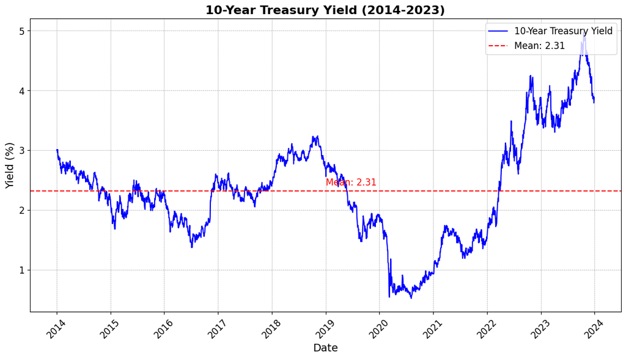

```python
# Handle missing values and convert date
dgs10.ffill(inplace=True)

# Calculate mean
mean_value = dgs10['DGS10'].mean()

# Plot
plt.figure(figsize=(14, 7))
plt.plot(dgs10['DATE'], dgs10['DGS10'], label="10-Year Treasury Yield", color="blue", linewidth=1.5)
plt.axhline(y=mean_value, color="red", linestyle="--", linewidth=1.5, label=f"Mean: {mean_value:.2f}")
plt.text(dgs10['DATE'].iloc[len(dgs10)//2], mean_value + 0.1, f"Mean: {mean_value:.2f}", color="red", fontsize=12)

# Add labels and title
plt.title("10-Year Treasury Yield (2014-2023)", fontsize=16, fontweight="bold")
plt.xlabel("Date", fontsize=14)
plt.ylabel("Yield (%)", fontsize=14)
plt.xticks(fontsize=12, rotation=45)
plt.yticks(fontsize=12)
plt.grid(color="gray", linestyle="--", linewidth=0.5, alpha=0.7)
plt.legend(fontsize=12, loc="upper right")

# Show
plt.show()
```

### Risk-Free Rate Calculation

The risk-free rate is a critical component in financial analysis, used as a baseline for calculating expected returns. In this section, we compute the daily risk-free rate using data from the 10-year U.S. Treasury yield (`DGS10`).

The code begins by loading the Treasury yield data and converting its values into a numeric format to handle potential non-numeric entries. It then filters the data to include only entries within the specified date range (`start_date` to `end_date`). This filtering ensures that the risk-free rate aligns with the period of our analysis.

If no data is available for the chosen timeframe, the function alerts the user and exits gracefully. Otherwise, it calculates the average annual risk-free rate over the selected period.

To make the risk-free rate applicable to daily stock return calculations, the annual rate is converted to a daily rate using compounding:

$$ \text{Daily Risk-Free Rate} = \left(1 + \text{Annual Risk-Free Rate}\right)^{\frac{1}{365}} - 1 $$

This transformation ensures that the risk-free rate is expressed in a format consistent with the daily returns of stocks and indices. The calculated daily risk-free rate is then printed and stored for use in subsequent computations, such as the expected return and abnormal return calculations.

```python
dgs10.set_index('DATE', inplace=True)

def get_rf_rate(dgs10, start_time, end_time):
    # Filter data within the specified date range
    filtered_df = dgs10[(dgs10.index >= start_time) & (dgs10.index <= end_time)]

    if filtered_df.empty:
        print("No data available in the specified date range.")
        return

    # Calculate the annual risk-free rate (in decimal form)
    filtered_df.loc[:,'DGS10'] = filtered_df['DGS10'] / 100

    # Convert the average annual risk-free rate to daily risk-free rate using compounding
    filtered_df = (1 + filtered_df) ** (1 / 365) - 1

    return filtered_df

rf_rate_daily = get_rf_rate(dgs10, start_date, end_date)
# Output the calculated daily risk-free rate
print(f"Daily Risk-Free Rate: {rf_rate_daily['DGS10'].mean():.6f}")
```

```
Daily Risk-Free Rate: 0.000062
```

```python
rf_rate_daily
```

| DATE | DGS10 |
| --- | --- |
| 2014-11-24 | 0.000062 |
| 2014-11-25 | 0.000061 |
| 2014-11-26 | 0.000061 |
| 2014-11-27 | 0.000061 |
| 2014-11-28 | 0.000059 |
| ... | ... |
| 2023-12-25 | 0.000105 |
| 2023-12-26 | 0.000105 |
| 2023-12-27 | 0.000102 |
| 2023-12-28 | 0.000103 |
| 2023-12-29 | 0.000104 |

2375 rows × 1 columns

# 6. Get industry price and excess return

## Excess Return and Industry Price Calculation

This section will calculate the excess returns of the specific industry group and that of the S&P 500 index, both very important in determining performance in excess of the risk-free rate.

This will first identify the tickers (stock symbols) of the target industry using the `industry_group` function, which extracts a list of companies from the grouped S&P 500 company data given an input sector, for instance, "Energy". Then, this list of industries selected will be the source to fetch the stock prices.

Using Yahoo Finance (`yf`), the daily historical stock price data for the companies in the industry group are downloaded for the defined date range (`start_date` to `end_date`). The closing prices are transformed from wide to long format for easier manipulation. The resulting dataset, `industry_price`, includes columns for the date, ticker symbol, and closing price.

Next, for each company in the industry group, daily returns are calculated. These are computed as the percent change in the closing price from day to day. Similarly, for the S&P 500 index, the daily returns are calculated.

Then, the excess return is computed for each asset class by subtracting the daily risk-free rate (previously calculated) from the daily returns. This gives two new columns, `excess_return`, one in the `industry_price` DataFrame and the other in the `SP500` DataFrame. Excess return is important because it demonstrates how well an asset has performed in relation to a baseline of zero-risk investment.

```python
def industry_group(grouped_data, name):
    '''
    The parameter:name is the sector name in grouped_data.
    '''
    industry_list = grouped_data.get(name, [])
    return industry_list


# Define intented date range
industry_list = industry_group(grouped_data, industry_name)

def download_data_in_batches(industry_list, start_date, end_date, batch_size=10):
    all_data = []  # List to store data from all batches

    # Split the industry list into batches of 10
    for i in range(0, len(industry_list), batch_size):
        tickers_batch = industry_list[i:i + batch_size]  # Get the current batch of tickers

        # Download the data for the batch
        data_batch = yf.download(tickers=tickers_batch, start=start_date, end=end_date)

        # Append the downloaded data to the all_data list
        all_data.append(data_batch)

        time.sleep(1)

    # Concatenate all the data into a single dataframe
    final_data = pd.concat(all_data, axis=1)

    return final_data


def get_return(start_date,end_date,industry_list):
    # Download real estate group data
    data = download_data_in_batches(industry_list, start_date, end_date, batch_size=len(industry_list))
    closing_prices = data['Close']
    closing_prices.reset_index(inplace=True)

    # Transform data from wide to long format
    industry_price = closing_prices.melt(id_vars=['Date'], var_name='ticker', value_name='close')
    industry_price.rename(columns={'Date': 'date'}, inplace=True)

    # Calculate daily returns for real estate group
    industry_price['return'] = industry_price.groupby('ticker')['close'].pct_change(fill_method=None)

    return industry_price

def get_excess_return_companies(industry_price, rf_rate_daily):
    data_list = []
    for _, sub_df in industry_price.groupby('ticker'):
        sub_merged_df = pd.merge(left = sub_df, right = rf_rate_daily, left_on='date', right_on=rf_rate_daily.index, how='inner')
        sub_merged_df['excess_return'] = sub_merged_df['return']-sub_merged_df.DGS10
        data_list.append(sub_merged_df)
    industry_price = pd.concat(data_list)
    return industry_price

# Calculate the excess return of S&P500 and companys in industry.
industry_price = get_return(start_date,end_date,industry_list)
industry_price = get_excess_return_companies(industry_price, rf_rate_daily)

# Calculate daily returns for S&P 500
def get_excess_return_SP(SP500, rf_rate_daily):
    SP500['return'] = SP500['Close/Last'].pct_change()
    merged_df = pd.merge(left = SP500, right = rf_rate_daily, left_on=SP500.index, right_on=rf_rate_daily.index, how='inner')
    merged_df['excess_return'] = merged_df['return']-merged_df.DGS10
    merged_df.rename({'key_0':"date"}, axis='columns',inplace=True)
    merged_df.set_index('date', inplace=True)
    return merged_df

SP500 = get_excess_return_SP(SP500, rf_rate_daily)
```

```
YF.download() has changed argument auto_adjust default to True
```

```
[*********************100%***********************]  31 of 31 completed
```

Let's now see the result of the `industry_price` data calculation to gauge the excess returns for companies making up the chosen industry group. This table will be a snapshot of the result, showing the date, the ticker symbol, closing prices, returns, and computed excess return for each of the companies making up the target industry.

```python
industry_price
```

|  | date | ticker | close | return | DGS10 | excess_return |
| --- | --- | --- | --- | --- | --- | --- |
| 0 | 2014-11-24 | AEE | 30.977924 | NaN | 0.000062 | NaN |
| 1 | 2014-11-25 | AEE | 30.912291 | -0.002119 | 0.000061 | -0.002180 |
| 2 | 2014-11-26 | AEE | 31.050842 | 0.004482 | 0.000061 | 0.004421 |
| 3 | 2014-11-28 | AEE | 31.437338 | 0.012447 | 0.000059 | 0.012388 |
| 4 | 2014-12-01 | AEE | 31.502974 | 0.002088 | 0.000060 | 0.002028 |
| ... | ... | ... | ... | ... | ... | ... |
| 2285 | 2023-12-22 | XEL | 59.264721 | 0.008614 | 0.000105 | 0.008509 |
| 2286 | 2023-12-26 | XEL | 59.446163 | 0.003062 | 0.000105 | 0.002957 |
| 2287 | 2023-12-27 | XEL | 59.263199 | -0.003078 | 0.000102 | -0.003180 |
| 2288 | 2023-12-28 | XEL | 59.600246 | 0.005687 | 0.000103 | 0.005584 |
| 2289 | 2023-12-29 | XEL | 59.619507 | 0.000323 | 0.000104 | 0.000219 |

70990 rows × 6 columns

```python
SP500
```

| date | Close/Last | Open | High | Low | return | DGS10 | excess_return |
| --- | --- | --- | --- | --- | --- | --- | --- |
| 2023-12-29 | 4769.83 | 4782.88 | 4788.43 | 4751.99 | 0.005693 | 0.000104 | 0.005589 |
| 2023-12-28 | 4783.35 | 4786.44 | 4793.30 | 4780.98 | 0.002834 | 0.000103 | 0.002731 |
| 2023-12-27 | 4781.58 | 4773.45 | 4785.39 | 4768.90 | -0.000370 | 0.000102 | -0.000472 |
| 2023-12-26 | 4774.75 | 4758.86 | 4784.72 | 4758.45 | -0.001428 | 0.000105 | -0.001533 |
| 2023-12-22 | 4754.63 | 4753.92 | 4772.94 | 4736.77 | -0.004214 | 0.000105 | -0.004319 |
| ... | ... | ... | ... | ... | ... | ... | ... |
| 2014-11-28 | 2067.56 | 2074.78 | 2075.76 | 2065.06 | 0.006876 | 0.000059 | 0.006817 |
| 2014-11-27 | 2072.83 | 0.00 | 0.00 | 0.00 | 0.002549 | 0.000061 | 0.002488 |
| 2014-11-26 | 2072.83 | 2067.36 | 2073.29 | 2066.62 | 0.000000 | 0.000061 | -0.000061 |
| 2014-11-25 | 2067.03 | 2070.15 | 2074.21 | 2064.75 | -0.002798 | 0.000061 | -0.002860 |
| 2014-11-24 | 2069.41 | 2065.07 | 2070.17 | 2065.07 | 0.001151 | 0.000062 | 0.001089 |

2301 rows × 7 columns

## Merging Industry and Market Excess Returns

Now we will merge the excess return data for the selected industry group and the S&P 500 index into a single DataFrame, `merged_df`. This merged dataset can be used to directly compare the performance of individual companies in the industry against that of the overall market.

The `pd.merge` function combines the two datasets by aligning their respective dates. It includes columns for `excess_return` for the `industry_price` DataFrame, which represents the individual assets, and for the `SP500` DataFrame, which represents the market. The dataset has explicit labels for distinguishing between the asset-specific excess returns and those of the market by using suffixes `_asset` and `_market`, respectively.

The advantage of this structure is that we will be able to perform deeper analysis, such as abnormal returns, and investigate the behavior of individual assets with respect to the general market during disaster periods.

```python
merged_df = pd.merge(
    industry_price[['date', 'ticker', 'excess_return']],
    SP500[['excess_return']],
    left_on='date',
    right_on=SP500.index,
    suffixes=('_asset', '_market'))

merged_df
```

|  | date | ticker | excess_return_asset | excess_return_market |
| --- | --- | --- | --- | --- |
| 0 | 2014-11-24 | AEE | NaN | 0.001089 |
| 1 | 2014-11-25 | AEE | -0.002180 | -0.002860 |
| 2 | 2014-11-26 | AEE | 0.004421 | -0.000061 |
| 3 | 2014-11-28 | AEE | 0.012388 | 0.006817 |
| 4 | 2014-12-01 | AEE | 0.002028 | -0.006404 |
| ... | ... | ... | ... | ... |
| 70985 | 2023-12-22 | XEL | 0.008509 | -0.004319 |
| 70986 | 2023-12-26 | XEL | 0.002957 | -0.001533 |
| 70987 | 2023-12-27 | XEL | -0.003180 | -0.000472 |
| 70988 | 2023-12-28 | XEL | 0.005584 | 0.002731 |
| 70989 | 2023-12-29 | XEL | 0.000219 | 0.005589 |

70990 rows × 4 columns

# 7. Abnormal Return

## Estimating Alpha, Beta, and Abnormal Returns Using CAPM

This code calculates key parameters — alpha and beta — for assets using the Capital Asset Pricing Model (CAPM) and computes the abnormal returns for each company in the selected industry group. Here's a step-by-step breakdown:

### CAPM and Its Importance

The CAPM framework helps estimate a stock's expected return based on its relationship with the broader market. It uses two key parameters:

1. **Alpha $( \alpha ) $**: Measures the excess return of an asset that cannot be explained by market movements.
2. **Beta $( \beta )$**: Indicates the sensitivity of an asset's return to the market return.

Abnormal returns are then derived by comparing the asset's actual excess return to its CAPM-predicted return.

## Step 1: Estimating CAPM Parameters

The `estimate_capm_sklearn` function performs linear regression to estimate the alpha and beta for each asset in the industry group:

- **Inputs**:
  - `excess_return_market`: The market’s excess return (S&P 500).
  - `excess_return_asset`: The asset’s excess return (individual stock).
- **Process**:
  - Data is first cleaned to drop any missing values.
  - A linear regression model is fitted where:
    - The market’s excess return is the independent variable $( x )$.
    - The asset’s excess return is the dependent variable $( y )$.
  - If the dataset is insufficient or constant (e.g., no variation in returns), NaN is returned for alpha and beta.
- **Outputs**:
  - **Alpha**: The regression intercept, representing the asset’s performance independent of market movements.
  - **Beta**: The regression coefficient, indicating the asset’s sensitivity to the market.

## Step 2: Calculating Abnormal Returns

The `calculate_abnormal_return` function uses the CAPM parameters to compute abnormal returns for each asset:

1. **Group Assets by Ticker**:
   - The data is grouped by stock ticker, and CAPM parameters (alpha and beta) are calculated for each group using the `estimate_capm_sklearn` function.
2. **Merge CAPM Parameters**:
   - The calculated alpha and beta values are merged back into the main dataset (`merged_df`) for each asset.
3. **Predicted Returns**:
   - CAPM is applied to calculate the predicted return for each asset:

     $$ \text{Abnormal Return} = \text{Excess Return (Asset)} - \text{Predicted Return} $$

## Step 3: Merging with Location Data

After calculating abnormal returns, the data is enriched by merging with location information from the S&P 500 company dataset. This step associates each company with its headquarters location, enabling geographic analysis of disaster impacts.

```python
# Function to estimate alpha and beta using CAPM
def estimate_capm_sklearn(group):
    """
    Perform linear regression: y (asset excess return) vs. x (market excess return).
    """
    group = group.dropna()
    x = group.excess_return_market.values.reshape(-1, 1)  # Market excess return
    y = group.excess_return_asset.values  # Asset excess return

    # Check if data is sufficient for regression
    if len(x) < 2 or np.all(x == x[0]) or np.all(y == y[0]):
        return pd.Series({'alpha': np.nan, 'beta': np.nan})  # Return NaN if insufficient or constant data

    # Fit linear regression
    model = LinearRegression().fit(x, y)

    # Extract alpha and beta
    alpha = model.intercept_  # Intercept corresponds to alpha
    beta = model.coef_[0]     # Coefficient corresponds to beta

    return pd.Series({'alpha': alpha, 'beta': beta})

def calculate_abnormal_return(merged_df, rf_rate_daily):

    # Group by ticker and calculate CAPM parameters
    capm_params = merged_df.groupby('ticker').apply(estimate_capm_sklearn, include_groups=False)

    # Add CAPM parameters to the merged dataset
    merged_df = merged_df.merge(capm_params, on='ticker')

    # Calculate CAPM predicted returns and abnormal returns
    merged_df['predicted_return'] = merged_df['alpha'] + merged_df['beta'] * merged_df['excess_return_market']
    merged_df['abnormal_return'] = merged_df['excess_return_asset'] - merged_df['predicted_return']

    # Merge with location data
    final_industry_df = merged_df.merge(
        SP500_companies[['Symbol', 'Location']],
        left_on='ticker',
        right_on='Symbol',
        how='inner'
    ).drop(columns=['excess_return_asset', 'excess_return_market', 'alpha', 'beta', 'predicted_return', 'Symbol'])

    return final_industry_df

final_industry_df = calculate_abnormal_return(merged_df, rf_rate_daily)
```

### Final Dataset

The resulting dataset, `final_industry_df`, contains the following key columns:

- **Date**: The date of each observation.
- **Ticker**: The stock ticker symbol of each company.
- **Abnormal Return**: The calculated abnormal return for each company.
- **Location**: The geographic location (state) of each company's headquarters.

This final dataset provides all the necessary information for analyzing the financial impacts of disasters on industry-specific companies, including their geographic distribution.

```python
final_industry_df
```

|  | date | ticker | abnormal_return | Location |
| --- | --- | --- | --- | --- |
| 0 | 2014-11-24 | AEE | NaN | MO |
| 1 | 2014-11-25 | AEE | -0.002257 | MO |
| 2 | 2014-11-26 | AEE | 0.003990 | MO |
| 3 | 2014-11-28 | AEE | 0.011086 | MO |
| 4 | 2014-12-01 | AEE | 0.002400 | MO |
| ... | ... | ... | ... | ... |
| 70985 | 2023-12-22 | XEL | 0.008655 | MN |
| 70986 | 2023-12-26 | XEL | 0.002704 | MN |
| 70987 | 2023-12-27 | XEL | -0.003585 | MN |
| 70988 | 2023-12-28 | XEL | 0.004719 | MN |
| 70989 | 2023-12-29 | XEL | -0.001056 | MN |

70990 rows × 4 columns

# 8. **Event Study**

## Checking Unique Disaster Types

Now, as we begin the main component of our event study, we would first like to inspect the unique disaster types present in the `location_based_df` dataset. This function is useful for identifying the different types of disasters included in the data, such as Floods, Tropical Cyclones, or Severe Storms, which will allow us to focus our analysis on specific types of events. The output of this command provides a list of disaster types that can be used to filter the dataset and isolate the events of interest for our event study.

```python
location_based_df.Disaster.unique()
```

```
array(['Severe Storm', 'Freeze', 'Flooding', 'Tropical Cyclone',
       'Winter Storm'], dtype=object)
```

## Filtering Disaster Data by Type

The `get_disaster_df` function is designed to filter the `location_based_df` dataset based on the specified disaster type. This function takes two inputs:

1. The `location_based_df`, which contains detailed information about various natural disasters.
2. The `disaster_type`, which specifies which kind of disaster (e.g., Flooding, Tropical Cyclone) we want to focus on.

By filtering the dataset in this way, we can narrow our analysis to a particular disaster type, ensuring that our study is focused on the events most relevant to our research question. The filtered data, `diaster_df`, contains only the rows corresponding to the selected disaster type.

```python
def get_disaster_df(location_based_df, disaster_type):
    diaster_df = location_based_df[location_based_df.Disaster==disaster_type]
    return diaster_df
```

## Calculating Abnormal Returns for Each Event

In this section, we calculate the abnormal returns for stocks in relation to specific disaster events to measure how disaster events affect stock prices. The process starts by filtering the dataset based on the selected disaster type (e.g., Flooding or Tropical Cyclones) using the `get_disaster_df` function. This allows us to focus our analysis on the chosen disaster type and exclude irrelevant data.

Once we have the relevant disaster data, we initialize an empty dictionary, `result_dict`, to store the abnormal returns for each event. Then, we use a for loop to iterate over each unique location in the `disaster_df`. For each location, we extract the disaster data (`storm_location_df`) and match it with the stock data of companies located in that same region (`stock_location_df`), which is stored in the `final_industry_df` DataFrame.

If no stock data exists for a particular location (i.e., the location-based stock data is empty), the loop simply skips that location, ensuring that we only process valid data. For each valid location, we then use another for loop to iterate over each row in the `storm_location_df` to get the start and end dates of the disaster event.

At this point, we attempt to locate the corresponding disaster event dates in the stock data by using the `get_loc()` method to find the indices for the begin and end dates. If either of the dates is missing from the stock data, we skip that event, as we cannot calculate abnormal returns for it.

When valid disaster dates are found, we check if there is sufficient data before and after the event window. Specifically, we ensure that the stock data for the time periods 30 days before and 30 days after the disaster event are available. If the event window is too close to the start or end of the available stock data, we skip that event.

If all conditions are met, we proceed to extract abnormal returns for the event window. This is done by calculating the stock's returns during three periods: before the event, during the event itself, and after the event. The abnormal returns are computed as the difference between the actual returns and the expected returns (based on market performance). We concatenate the abnormal returns for the before, during, and after windows into a single time series for the disaster event.

These abnormal returns are then added to the `result_dict`, with each key representing a combination of location, disaster start date, and company ticker symbol. This allows us to keep track of abnormal returns for each event separately.

After all abnormal returns are calculated, we combine the results into a single DataFrame (`abnormal_returns_df`), where each row represents a specific event. From this DataFrame, we calculate the **Average Abnormal Return (AAR)** by averaging the abnormal returns across all events at each time point. This gives us a measure of the typical market response to disasters at different times relative to the event. The **Cumulative Average Abnormal Return (CAAR)** is then computed by taking the cumulative sum of the AAR, which helps us understand the long-term impact of disasters on stock prices.

This process allows us to analyze the immediate and ongoing financial impacts of natural disasters on specific industries, providing valuable insights into market reactions.

```python
disaster_df = get_disaster_df(location_based_df, disaster_type)

def get_caar(final_industry_df, disaster_df):
    result_dict = {}  # Store abnormal returns for each event

    for location in disaster_df['Location'].unique():
        storm_location_df = disaster_df[disaster_df['Location'] == location]
        stock_location_df = final_industry_df[final_industry_df['Location'] == location]

        if stock_location_df.empty:
            continue

        for _, storm_row in storm_location_df.iterrows():
            begin_date = storm_row['Begin Date']
            end_date = storm_row['End Date']

            for ticker, stock_group in stock_location_df.groupby('ticker'):
                stock_group = stock_group.set_index('date')

                try:
                    begin_idx = stock_group.index.get_loc(begin_date)
                    end_idx = stock_group.index.get_loc(end_date)
                except KeyError:
                    continue

                if (begin_idx - day_num < 0) or (end_idx + day_num >= len(stock_group.index)):
                    continue

                # Extract abnormal returns for the event window
                before_window = stock_group.iloc[begin_idx - day_num:begin_idx]['abnormal_return']
                after_window = stock_group.iloc[end_idx:end_idx + day_num]['abnormal_return']
                event_window = stock_group.iloc[begin_idx:end_idx]['abnormal_return']
                sum_ab_return = event_window.sum()

                abnormal_returns = pd.concat([before_window, pd.Series([sum_ab_return]), after_window]).reset_index(drop=True)

                # Add to result dictionary (keyed by event)
                result_dict[(location, begin_date, ticker)] = abnormal_returns

    # Combine all abnormal returns into a DataFrame
    abnormal_returns_df = pd.DataFrame(result_dict).T  # Transpose for time-series format

    # Calculate AAR and CAAR
    aar = abnormal_returns_df.mean()  # Average across events for each time point
    caar = aar.cumsum()  # Cumulative sum of AAR

    return aar, caar

aar, caar = get_caar(final_industry_df, disaster_df)
```

#### Viewing the Average Abnormal Return (AAR)

This step displays the calculated Average Abnormal Return (AAR). The AAR shows the average abnormal returns for the stocks across all disaster events over the defined event window. By examining this metric, we can understand the overall market response to the disaster, including whether stock prices, on average, reacted positively or negatively.

```python
aar
```

```
0     0.000374
1    -0.004701
2    -0.006039
3    -0.008642
4    -0.005827
        ...
56   -0.004301
57   -0.000601
58    0.002657
59    0.002616
60   -0.007650
Length: 61, dtype: float64
```

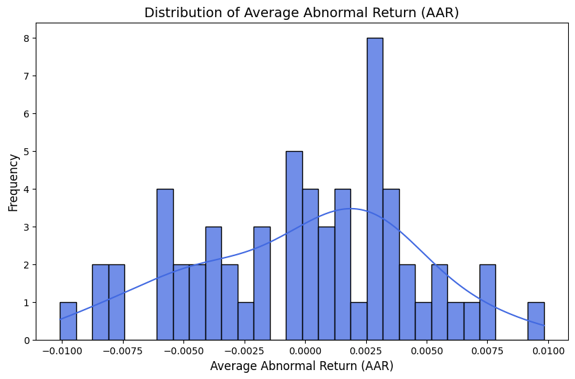

```python
# Set the figure size for better visibility
plt.figure(figsize=(10, 6))

# Create a histogram for Average Abnormal Return (AAR)
sns.histplot(aar, bins=30, kde=True, color='royalblue', alpha=0.75)

# Add labels and title
plt.xlabel('Average Abnormal Return (AAR)', fontsize=12)
plt.ylabel('Frequency', fontsize=12)
plt.title('Distribution of Average Abnormal Return (AAR)', fontsize=14)

# Show the plot
plt.show()
```

## Viewing the Cumulative Average Abnormal Return (CAAR) Plot

This plot visualizes the cumulative average abnormal return (CAAR) over the event window. By plotting CAAR, we can see the total impact of the disaster events on stock prices over time. The plot helps us understand the cumulative effect of abnormal returns across multiple events, providing insight into how stock prices recover (or fail to recover) in the aftermath of disasters.

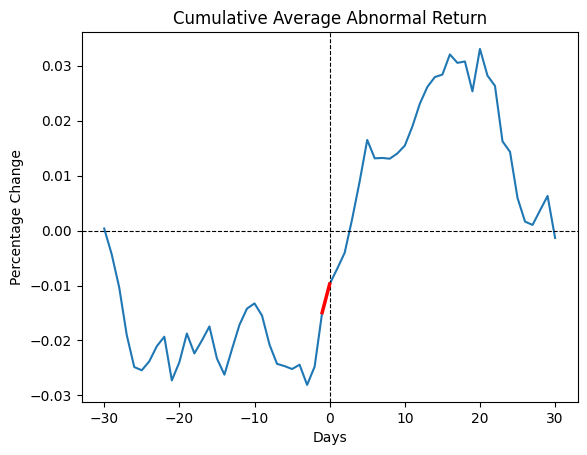

```python
fig, ax = plt.subplots(1)
ax.plot(range(-day_num, day_num + 1), caar, label='caar')
ax.axhline(0, color='black', linewidth=0.8, linestyle='--')
ax.axvline(x=0, color='black', linestyle='--',linewidth=0.8)
ax.set_title(f"Cumulative Average Abnormal Return")
ax.set_xlabel("Days")
ax.set_ylabel("Percentage Change")
x_values = range(-day_num, day_num + 1)  # X values
y_values = caar  # CAAR values
mask = [-1 <= x <= 0 for x in x_values]
ax.plot([x for x, m in zip(x_values, mask) if m],
        [y for y, m in zip(y_values, mask) if m],
        color='red', linewidth=2.5)
plt.show()
```

### What the CAAR Plot shows us:

The CAAR plot illustrates the **Cumulative Average Abnormal Returns (CAAR)** over a 60-day period, spanning **30 days before and after** a specific event. The **x-axis** represents time, with **day 0** marking the event, while the **y-axis** shows the cumulative percentage change in abnormal returns.

In the **pre-event period** (days **-30 to -1**), CAAR fluctuates but generally trends negative, suggesting some degree of market anticipation or cautious sentiment leading up to the disaster. During the **event window** (**day -1 to day 0**, marked by the red line), there is a noticeable increase in CAAR, indicating an immediate market reaction—potentially reflecting investor confidence or the perceived stability of the affected industry.

Following the event, CAAR continues to rise, peaking around **20 days post-event**. This sustained increase suggests a period of market adjustment as investors factor in recovery efforts, potential government support, or increased demand within the affected industry. However, after reaching its peak, CAAR declines, signaling a return to normalcy as the market stabilizes.

Overall, the plot highlights the market’s initial response, followed by a recovery phase and eventual stabilization. This pattern suggests that while disasters may initially disrupt stock prices, certain industries demonstrate resilience, with investors potentially viewing them as opportunities for recovery-driven growth.

# 9. Comprehensive Visualization

After conducting extensive research and analysis, we identified three key industries: **Utilities, Real Estate, and Energy**, and three major disaster types: **Tropical Cyclone, Flooding, and Severe Storm**, that demonstrate the most significant and noticeable impacts.

```python
# Define intented date range
start_date = '2014-11-24'
end_date = '2023-12-31'

day_num = 30 # The time window we are reasearching

# Define the industries and disaster types for the 3x3 grid
industries = ["Utilities", "Real Estate", "Energy"]
disaster_types = ["Flooding", "Tropical Cyclone", "Severe Storm"]

rf_rate_daily = get_rf_rate(dgs10,start_date, end_date)

# If you run the code blocks before, you don't need to calculate the SP500 again.
# Calculate daily returns for S&P 500
# SP500 = get_excess_return_SP(SP500, rf_rate_daily)
```

[output not shown]

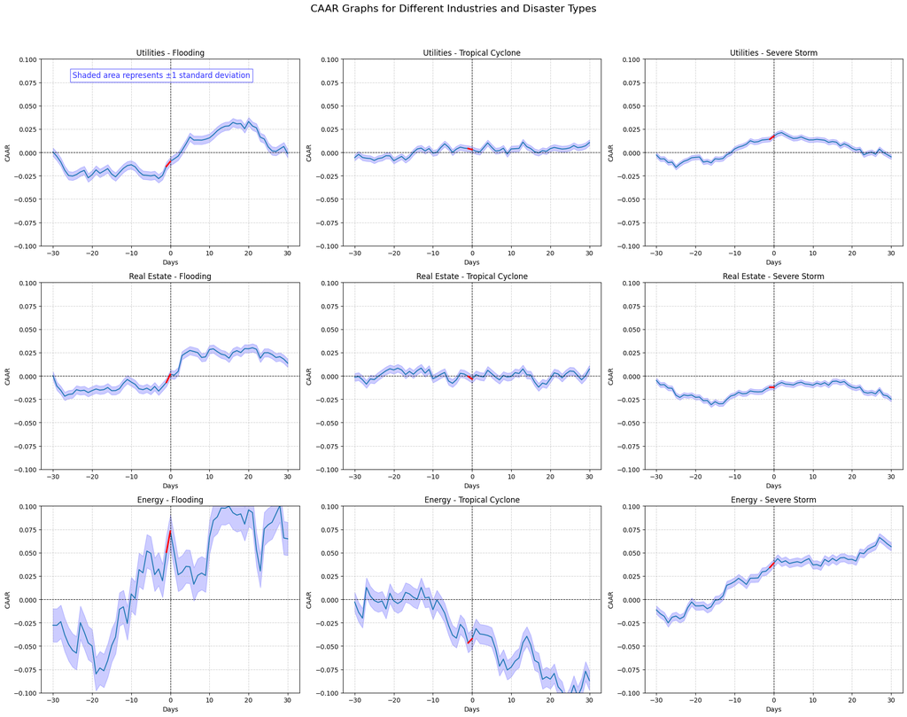

```python
# Plot the 3x3 grid of CAAR graphs
fig, axes = plt.subplots(3, 3, figsize=(20,16))
fig.suptitle('CAAR Graphs for Different Industries and Disaster Types', fontsize=16)

for i, industry in enumerate(industries):
    for j, disaster in enumerate(disaster_types):
        industry_list = industry_group(grouped_data, industry)
        # Calculate the excess return of S&P500 and companys in industry.
        industry_price = get_return(start_date,end_date,industry_list)
        industry_price = get_excess_return_companies(industry_price, rf_rate_daily)

        merged_df = pd.merge(
            industry_price[['date', 'ticker', 'excess_return']],
            SP500[['excess_return']],
            left_on='date',
            right_on=SP500.index,
            suffixes=('_asset', '_market'))

        final_industry_test = calculate_abnormal_return(merged_df, rf_rate_daily)
        disaster_test = get_disaster_df(location_based_df, disaster)
        arr, caar =  get_caar(final_industry_test, disaster_test)

        ax = axes[i, j]
        ax.plot(range(-day_num, day_num + 1), caar)
        ax.axhline(0, color='black', linewidth=0.8, linestyle='--')
        ax.set_title(f"{industry} - {disaster}")
        ax.set_xlabel("Days")
        ax.set_ylabel("CAAR")
        ax.axvline(x=0, color='black', linestyle='--',linewidth=0.8)
        ax.set_ylim(-0.1, 0.1)
        ax.grid(True, linestyle='--', alpha=0.6)

        std_dev = np.std(arr, axis=0)
        upper_bound = caar + std_dev
        lower_bound = caar - std_dev

        ax.fill_between(range(-day_num, day_num + 1), lower_bound, upper_bound, color='blue', alpha=0.2)

        if all([i == 0, j == 0]):
            # Add a text annotation to explain the shaded confidence interval
            ax.text(-day_num + 5, 0.08,
                            "Shaded area represents ±1 standard deviation",
                            fontsize=12, color='blue', alpha=0.8,
                            bbox=dict(facecolor='white', alpha=0.6, edgecolor='blue'))

        x_values = range(-day_num, day_num + 1)  # X values
        y_values = caar  # CAAR values
        mask = [-1 <= x <= 0 for x in x_values]
        ax.plot([x for x, m in zip(x_values, mask) if m],
                [y for y, m in zip(y_values, mask) if m],
                color='red', linewidth=2.5)


plt.tight_layout(rect=[0, 0, 1, 0.95])  # Adjust layout to fit the title
plt.show()
```

## **Observations**

**The red line represents the event window, spanning from the day the disaster occurred to the day it ended, highlighting market reactions during the event period.**  
The **blue-shaded area** denotes the **one-standard-deviation confidence interval**.

### **Utilities Sector**

For **Tropical Cyclones** and **Severe Storms**, CAAR remains relatively stable and close to zero both before, during, and after the event, indicating that these disasters have minimal impact on the sector. However, in the case of **Flooding**, there is a significant long-term increase in CAAR during the event window, reflecting strong immediate market confidence. The upward trend continues, peaking approximately 20 days post-event, demonstrating the sector's resilience and growth potential.

Possible explanations for this phenomenon include:

- **Surge in post-disaster restoration demand** → Short-term revenue growth expectations
- **Government subsidies & insurance compensation** → Improved financial stability
- **Inelastic demand** → Stable cash flow and lower financing costs
- **Defensive asset appeal** → Increased capital inflow, pushing stock prices higher

### **Real Estate Sector**

For **Tropical Cyclones** and **Severe Storms**, CAAR remains stable and close to zero throughout the event window, suggesting limited impact. However, in the case of **Flooding**, there is a notable and immediate rise in CAAR during the event window, which continues to climb over the subsequent weeks. This highlights the sector's strong potential for post-disaster recovery and growth.

Possible explanations include:

- **Increased demand for reconstruction and property repairs** → Higher revenue expectations for real estate developers and contractors
- **Government intervention and financial support** → Stabilization of housing markets and recovery incentives
- **Expectations of rising property values in unaffected areas** → Increased investment activity in resilient markets

### **Energy Sector**

For **Tropical Cyclones**, the sector exhibits a prolonged negative trend in CAAR during and after the event window, with continued losses in the following days. This suggests the sector's vulnerability to such events, likely due to operational disruptions and infrastructure damage.

#### Aditional information about Tropical Cyclones and Severe Storms

| **Aspect** | **Tropical Cyclones (热带气旋)** | **Severe Storms (严重风暴)** |
| --- | --- | --- |
| **Definition** | Strong, rotating low-pressure systems that develop over warm ocean waters, including hurricanes and typhoons. | Includes thunderstorms, tornadoes, hailstorms, and strong winds. |
| **Formation** | Formed over warm ocean waters, relying on heat and moisture for energy. | Triggered by atmospheric instability, cold and warm air mass collisions. |
| **Structure** | Characterized by a well-defined, symmetrical structure, often with an "eye" at the center. | Structure varies widely, not always symmetric, may include swirling winds or thunderstorms. |
| **Wind Speed** | Can exceed 250 km/h (155 mph), with the strongest winds near the eye. | Winds are typically less than 150 km/h (93 mph), but tornadoes can exceed 300 km/h (186 mph). |
| **Precipitation** | Intense rainfall over a long period, often lasting several days. | Generally short-term but intense rainfall, often in the form of hail or heavy showers. |
| **Impact Area** | Can span hundreds of kilometers, affecting a vast area. | Usually more localized, often affecting areas within tens of kilometers. |
| **Duration** | Lasts from several days to weeks. | Usually lasts from hours to a day, but tornadoes can last just minutes. |
| **Typical Occurrence** | Primarily occurs in tropical and subtropical ocean regions, such as the Atlantic and Pacific Oceans. | Common in mid-latitudes, especially North America, Europe, and Australia. |
| **Damage Type** | Strong winds, storm surges, flooding, and significant infrastructure damage. | Can cause lightning strikes, hail damage, tornadoes, flash floods, and local power outages. |
| **Examples** | Hurricane Katrina (2005), Typhoon Haiyan (2013). | Joplin Tornado (2011), Storm Kyrill (2007). |
| **Economic Impact** | Large-scale infrastructure damage, insurance claims, disruption of local economies, and long-term recovery costs. | Localized disruptions, damage to crops, buildings, and energy infrastructure. |

# 10. Correlation Analysis(For specific disaster and industry)

Next, we aim to explore the correlation between the loss amount and the average abnormal returns of companies in response to the disaster, in order to assist in making stock investment decisions when facing natural disasters of varying scales. We choose the utilities sector and perform a correlation analysis between the five-day post-flood AR and the flooding-induced losses.

```python
# Select the flooding disasters.
sub_disaster_df = get_disaster_df(location_based_df, 'Flooding')
sub_disaster_df
```

|  | Name | Disaster | Begin Date | End Date | CPI-Adjusted Cost | Unadjusted Cost | Deaths | Location | day_num | int_day_num |
| --- | --- | --- | --- | --- | --- | --- | --- | --- | --- | --- |
| 82 | Missouri and Arkansas Flooding and Central Sev... | Flooding | 2017-04-25 | 2017-05-07 | 2156.7 | 1659.0 | 20 | AL | 12 days | 12 |
| 176 | Texas and Oklahoma Flooding and Severe Weather... | Flooding | 2015-05-23 | 2015-05-26 | 3375.6 | 2500.4 | 31 | AR | 3 days | 3 |
| 182 | Missouri and Arkansas Flooding and Central Sev... | Flooding | 2017-04-25 | 2017-05-07 | 2156.7 | 1659.0 | 20 | AR | 12 days | 12 |
| 245 | California Flooding and Severe Weather (Januar... | Flooding | 2021-01-24 | 2021-01-29 | 1314.0 | 1095.0 | 2 | AZ | 5 days | 5 |
| 284 | California Flooding (February 2017) | Flooding | 2017-02-08 | 2017-02-22 | 1950.0 | 1500.0 | 5 | CA | 14 days | 14 |
| ... | ... | ... | ... | ... | ... | ... | ... | ... | ... | ... |
| 3289 | East Coast Storm and Flooding (December 2023) | Flooding | 2023-12-16 | 2023-12-18 | 1301.6 | 1276.0 | 5 | VA | 2 days | 2 |
| 3320 | Northeastern Flooding and North Central Severe... | Flooding | 2023-07-09 | 2023-07-15 | 2230.4 | 2165.0 | 10 | VT | 6 days | 6 |
| 3394 | Missouri River and North Central Flooding (Mar... | Flooding | 2019-03-14 | 2019-03-31 | 13408.9 | 10727.0 | 3 | WI | 17 days | 17 |
| 3411 | Northeastern Flooding and North Central Severe... | Flooding | 2023-07-09 | 2023-07-15 | 2230.4 | 2165.0 | 10 | WI | 6 days | 6 |
| 3453 | West Virginia Flooding and Ohio Valley Tornado... | Flooding | 2016-06-22 | 2016-06-24 | 1288.5 | 968.8 | 23 | WV | 2 days | 2 |

76 rows × 10 columns

```python
# If you run the code blocks before, you don't need to calculate the SP500 again.
# Calculate daily returns for S&P 500
# SP500 = get_excess_return_SP(SP500, rf_rate_daily)

# Select the energy companies in the S&P500.
industry_list = industry_group(grouped_data, 'Utilities')

# Calculate the excess return of S&P500 and companys in industry.
industry_price = get_return(start_date,end_date,industry_list)
industry_price = get_excess_return_companies(industry_price, rf_rate_daily)

merged_df = pd.merge(
            industry_price[['date', 'ticker', 'excess_return']],
            SP500[['excess_return']],
            left_on='date',
            right_on=SP500.index,
            suffixes=('_asset', '_market'))

final_industry_test = calculate_abnormal_return(merged_df, rf_rate_daily)
final_industry_test
```

```
[*********************100%***********************]  31 of 31 completed
```

|  | date | ticker | abnormal_return | Location |
| --- | --- | --- | --- | --- |
| 0 | 2014-11-24 | AEE | NaN | MO |
| 1 | 2014-11-25 | AEE | -0.002257 | MO |
| 2 | 2014-11-26 | AEE | 0.003991 | MO |
| 3 | 2014-11-28 | AEE | 0.011085 | MO |
| 4 | 2014-12-01 | AEE | 0.002400 | MO |
| ... | ... | ... | ... | ... |
| 70985 | 2023-12-22 | XEL | 0.008655 | MN |
| 70986 | 2023-12-26 | XEL | 0.002704 | MN |
| 70987 | 2023-12-27 | XEL | -0.003585 | MN |
| 70988 | 2023-12-28 | XEL | 0.004719 | MN |
| 70989 | 2023-12-29 | XEL | -0.001056 | MN |

70990 rows × 4 columns

```python
# Get the abnormal returns after flooding in different regions.
data_dict = {}

for index, row in sub_disaster_df.iterrows():
    stock_location_df = final_industry_test[final_industry_test['Location']==row.Location]
    if stock_location_df.empty:
        # !!
        continue
    begin_date = row['Begin Date']
    end_date = row['End Date']
    disaster_loss = row['CPI-Adjusted Cost']
    for ticker, stock_group in stock_location_df.groupby('ticker'):
        stock_group = stock_group.set_index('date')

        try:
            begin_idx = stock_group.index.get_loc(begin_date)
            end_idx = stock_group.index.get_loc(end_date)
        except KeyError:
            continue

        if (begin_idx - day_num < 0) or (end_idx + day_num >= len(stock_group.index)):
            continue

        # Extract abnormal returns for the event window
        abnormal_return = stock_group.iloc[begin_idx:end_idx+5]['abnormal_return'].sum()
        data_dict[index]={'disaster_name':row.Name, 'disaster_loss':disaster_loss, 'abnormal_return':abnormal_return}


# Standarization of CPI-Adjustment Cost
def standard_normalize(series):
    series = pd.to_numeric(series)
    # z_score standarization
    mean = series.mean()
    std = series.std()
    return (series - mean) / std

fianl_df = pd.DataFrame(data_dict).T.set_index('disaster_name',drop=True)
fianl_df['disaster_loss']=standard_normalize(fianl_df['disaster_loss'])
fianl_df
```

| disaster_name | disaster_loss | abnormal_return |
| --- | --- | --- |
| California Flooding (February 2017) | -0.216507 | 0.07288 |
| Fort Lauderdale Flash Flood (April 2023) | -0.477734 | 0.005042 |
| West Virginia Flooding and Ohio Valley Tornadoes (June 2016) | -0.428015 | 0.044047 |
| West Virginia Flooding and Ohio Valley Tornadoes (June 2016) | -0.428015 | 0.045027 |
| Louisiana Flooding (August 2016) | 3.412538 | -0.018564 |
| Louisiana Flooding (May 2021) | -0.338136 | -0.005332 |
| South Carolina and East Coast Flooding (October 2015) | 0.003378 | 0.0 |
| Kentucky and Missouri Flooding (July 2022) | -0.343476 | 0.055693 |
| South Carolina and East Coast Flooding (October 2015) | 0.003378 | 0.008709 |
| South Carolina and East Coast Flooding (October 2015) | 0.003378 | 0.005674 |
| West Virginia Flooding and Ohio Valley Tornadoes (June 2016) | -0.428015 | 0.039528 |
| Louisiana Flooding (May 2021) | -0.338136 | 0.013138 |
| South Carolina and East Coast Flooding (October 2015) | 0.003378 | 0.016785 |
| West Virginia Flooding and Ohio Valley Tornadoes (June 2016) | -0.428015 | 0.047946 |

```python
# Caculate the correlation coefficient between disaster_loss and abnormal_return.
fianl_df.corr()
```

|  | disaster_loss | abnormal_return |
| --- | --- | --- |
| disaster_loss | 1.000000 | -0.511466 |
| abnormal_return | -0.511466 | 1.000000 |

```python
# Linear Regression
X = pd.to_numeric(fianl_df['disaster_loss'])
y = pd.to_numeric(fianl_df['abnormal_return'])

X = sm.add_constant(X)

model = sm.OLS(y, X)  # OLS
result = model.fit()
# Regression summary
result.summary()
```

OLS Regression Results

| Dep. Variable: | abnormal_return | R-squared: | 0.262 |
| --- | --- | --- | --- |
| Model: | OLS | Adj. R-squared: | 0.200 |
| Method: | Least Squares | F-statistic: | 4.251 |
| Date: | Sun, 23 Feb 2025 | Prob (F-statistic): | 0.0616 |
| Time: | 10:44:57 | Log-Likelihood: | 33.402 |
| No. Observations: | 14 | AIC: | -62.80 |
| Df Residuals: | 12 | BIC: | -61.53 |
| Df Model: | 1 |  |  |
| Covariance Type: | nonrobust |  |  |

|  | coef | std err | t | P>\|t\| | [0.025 | 0.975] |
| --- | --- | --- | --- | --- | --- | --- |
| const | 0.0236 | 0.006 | 3.674 | 0.003 | 0.010 | 0.038 |
| disaster_loss | -0.0138 | 0.007 | -2.062 | 0.062 | -0.028 | 0.001 |

| Omnibus: | 0.644 | Durbin-Watson: | 2.143 |
| --- | --- | --- | --- |
| Prob(Omnibus): | 0.725 | Jarque-Bera (JB): | 0.660 |
| Skew: | 0.351 | Prob(JB): | 0.719 |
| Kurtosis: | 2.201 | Cond. No. | 1.04 |

Notes:  
[1] Standard Errors assume that the covariance matrix of the errors is correctly specified.

## Correlation Analysis Conclusion

# 11. Conclusion

The research question posed was: *What are the immediate and short-term financial impacts of Floods, Cyclones, and Storms on the stock prices of U.S. companies, and how do these impacts vary across industries?* Our analysis reveals that the impacts of these disasters differ significantly across the Utilities, Real Estate, and Energy sectors.

In conclusion, this study aimed to examine the immediate and short-term financial impacts of floods, cyclones, and storms on the stock prices of U.S. companies, with a focus on how these effects vary across industries. The findings reveal significant differences in the way these disasters affect the Utilities, Real Estate, and Energy sectors. Each industry exhibits unique patterns of market reaction, reflecting their varying levels of resilience, adaptability, and exposure to disaster-related risks. These insights highlight the importance of industry-specific strategies for disaster preparedness and recovery, emphasizing the need for tailored approaches to mitigate financial vulnerabilities and capitalize on post-disaster opportunities

### How This Research Can Help Us

This research provides valuable insights for various stakeholders. **Investors** can use these findings to identify industries and disaster types that create opportunities for financial gains or present significant risks. For example, Utilities and Real Estate show strong recovery trends post-flooding, making them attractive targets for disaster-responsive portfolios. **Policymakers** can leverage these insights to prioritize disaster resilience strategies, such as investing in infrastructure for Utilities and supporting Energy systems during storms. **Businesses** can refine disaster preparedness plans, ensuring they mitigate operational disruptions while capitalizing on recovery-driven opportunities. Overall, this research equips stakeholders with data-driven strategies to better navigate the financial impacts of natural disasters.

### Opportunities For Improvement

While this research provides meaningful insights, there are areas for improvement to achieve more accurate and comprehensive results.

1. **Expanding the Dataset**: Including a broader range of industries and more geographically diverse companies could reveal regional variations in disaster impacts.
2. **Incorporating Additional Disaster Types**: Analyzing disasters such as wildfires or droughts would provide a more holistic understanding of market responses.
3. **Incorporating Additional Industry Types**: Analyzing industries such as insurance and medical would provide a more holistic understanding of market responses.
4. **Integrating Qualitative Factors**: Considering policy interventions or consumer behavior shifts could enrich the analysis.
5. **Using Advanced Models**: Future research should explore an empirical finance approach by using the **implied returns of stocks during periods without natural disasters** as a benchmark, rather than relying solely on **returns estimated using the CAPM model**. This would provide a more rigorous and realistic measure of abnormal returns.

By addressing these areas, future research can provide more robust and actionable insights into the financial impacts of natural disasters.

### Limitations We Faced Throughout The Creation

- The data we used for stock prices is from the top indexes in the world, meaning that each company we used would already have plentiful resources to evade majority of the effects of the disasters leading to smaller decreases in comparison to a small or medium sized business. These same businesses also would not be land-locked to a certain state and would have portfolios throughout the US and sometimes through the world negating the impact of the disaster further.
- Due to the previous point, our timeframes for the different datasets that we had differed massively (We went from have a range of 1980-2023 to 2000-2023 to 2014-2023). Meaning that our dataset got smaller and smaller as we tried to find better data.

# 12. Authors

This project was initially conceived by Jinbo Zhou as part of a course assignment for ECON323 at the University of British Columbia (UBC) from September 2024 to December 2024. The project, along with the primary research approach, was developed by Jinbo and completed by a group consisting of Jinbo Zhou, Michael Li, Siya Kuhu Shumbhan, and Manan Shah. However, due to time constraints during the course, the completion of the assignment was limited. In February 2025, Jinbo enhanced the project by providing more detailed explanations, visualizations, and subsequent analyses, improving the overall completion of the assignment. This version was finalized in February 2025.

# 13. References

1. NOAA Billion-Dollar Disasters Database: https://www.ncei.noaa.gov/access/billions/
2. S&P 500 Index Data: https://www.nasdaq.com/market-activity/index/spx/historical?page=1&rows_per_page=10&timeline=y10
3. Market Yield on U.S. Treasury Securities at 10-Year Constant Maturity, Quoted on an Investment Basis: https://fred.stlouisfed.org/series/DGS10
4. Yahoo Finance API for Historical Closing Prices of S&P 500 Companies:
- Python package: https://pypi.org/project/yfinance/
- Documentation and stock data retrieval: https://finance.yahoo.com/